# Risk Factor Analysis

## Outcome Variable

**Outcome Variable:** whz

## Predictor Variables

**Intervention Variable:** impfloor

**Adjustment Set:**

- arm
- sex
- W_mage
- meducyrs
- feducyrs
- hhwealth_quart
- hfoodsec
- W_mhtcm
- W_mwtkg
- W_mbmi
- W_nrooms
- W_nchldlt5
- W_parity
- impsan
- safeh20
- delta_W_mage
- delta_meducyrs
- delta_feducyrs
- delta_hhwealth_quart
- delta_hfoodsec
- delta_W_mhtcm
- delta_W_mwtkg
- delta_W_mbmi
- delta_W_nrooms
- delta_W_nchldlt5
- delta_W_parity
- delta_impsan
- delta_safeh20

## Stratifying Variables

The analysis was stratified on these variable(s):

- agecat
- studyid
- country

## Data Summary

| agecat | studyid | country | impfloor | n_cell | n |
| --- | --- | --- | --- | --- | --- |
| Birth | ki0047075b-MAL-ED | BANGLADESH | 1 | 185 | 201 |
| Birth | ki0047075b-MAL-ED | BANGLADESH | 0 | 16 | 201 |
| Birth | ki0047075b-MAL-ED | BRAZIL | 1 | 55 | 57 |
| Birth | ki0047075b-MAL-ED | BRAZIL | 0 | 2 | 57 |
| Birth | ki0047075b-MAL-ED | INDIA | 1 | 33 | 39 |
| Birth | ki0047075b-MAL-ED | INDIA | 0 | 6 | 39 |
| Birth | ki0047075b-MAL-ED | NEPAL | 1 | 8 | 24 |
| Birth | ki0047075b-MAL-ED | NEPAL | 0 | 16 | 24 |
| Birth | ki0047075b-MAL-ED | PERU | 1 | 37 | 210 |
| Birth | ki0047075b-MAL-ED | PERU | 0 | 173 | 210 |
| Birth | ki0047075b-MAL-ED | SOUTH AFRICA | 1 | 86 | 95 |
| Birth | ki0047075b-MAL-ED | SOUTH AFRICA | 0 | 9 | 95 |
| Birth | ki0047075b-MAL-ED | TANZANIA, UNITED REPUBLIC OF | 1 | 5 | 111 |
| Birth | ki0047075b-MAL-ED | TANZANIA, UNITED REPUBLIC OF | 0 | 106 | 111 |
| Birth | ki1000108-CMC-V-BCS-2002 | INDIA | 1 | 68 | 68 |
| Birth | ki1000108-CMC-V-BCS-2002 | INDIA | 0 | 0 | 68 |
| Birth | ki1000108-IRC | INDIA | 1 | 253 | 253 |
| Birth | ki1000108-IRC | INDIA | 0 | 0 | 253 |
| Birth | ki1017093-NIH-Birth | BANGLADESH | 1 | 505 | 572 |
| Birth | ki1017093-NIH-Birth | BANGLADESH | 0 | 67 | 572 |
| Birth | ki1017093b-PROVIDE | BANGLADESH | 1 | 485 | 532 |
| Birth | ki1017093b-PROVIDE | BANGLADESH | 0 | 47 | 532 |
| Birth | ki1017093c-NIH-Crypto | BANGLADESH | 1 | 542 | 707 |
| Birth | ki1017093c-NIH-Crypto | BANGLADESH | 0 | 165 | 707 |
| Birth | ki1113344-GMS-Nepal | NEPAL | 1 | 97 | 503 |
| Birth | ki1113344-GMS-Nepal | NEPAL | 0 | 406 | 503 |
| Birth | ki1114097-CONTENT | PERU | 1 | 2 | 2 |
| Birth | ki1114097-CONTENT | PERU | 0 | 0 | 2 |
| Birth | kiGH5241-JiVitA-3 | BANGLADESH | 1 | 1215 | 17966 |
| Birth | kiGH5241-JiVitA-3 | BANGLADESH | 0 | 16751 | 17966 |

[output cut: 66 more lines]

The following strata were considered:

- agecat: 24 months, studyid: ki0047075b-MAL-ED, country: BANGLADESH
- agecat: 24 months, studyid: ki0047075b-MAL-ED, country: BRAZIL
- agecat: 24 months, studyid: ki0047075b-MAL-ED, country: INDIA
- agecat: 24 months, studyid: ki0047075b-MAL-ED, country: NEPAL
- agecat: 24 months, studyid: ki0047075b-MAL-ED, country: PERU
- agecat: 24 months, studyid: ki0047075b-MAL-ED, country: SOUTH AFRICA
- agecat: 24 months, studyid: ki0047075b-MAL-ED, country: TANZANIA, UNITED REPUBLIC OF
- agecat: 24 months, studyid: ki1000108-CMC-V-BCS-2002, country: INDIA
- agecat: 24 months, studyid: ki1000108-IRC, country: INDIA
- agecat: 24 months, studyid: ki1017093-NIH-Birth, country: BANGLADESH
- agecat: 24 months, studyid: ki1017093b-PROVIDE, country: BANGLADESH
- agecat: 24 months, studyid: ki1017093c-NIH-Crypto, country: BANGLADESH
- agecat: 24 months, studyid: ki1113344-GMS-Nepal, country: NEPAL
- agecat: 24 months, studyid: ki1114097-CONTENT, country: PERU
- agecat: 24 months, studyid: kiGH5241-JiVitA-3, country: BANGLADESH
- agecat: 24 months, studyid: kiGH5241-JiVitA-4, country: BANGLADESH
- agecat: 6 months, studyid: ki0047075b-MAL-ED, country: BANGLADESH
- agecat: 6 months, studyid: ki0047075b-MAL-ED, country: BRAZIL
- agecat: 6 months, studyid: ki0047075b-MAL-ED, country: INDIA
- agecat: 6 months, studyid: ki0047075b-MAL-ED, country: NEPAL
- agecat: 6 months, studyid: ki0047075b-MAL-ED, country: PERU
- agecat: 6 months, studyid: ki0047075b-MAL-ED, country: SOUTH AFRICA
- agecat: 6 months, studyid: ki0047075b-MAL-ED, country: TANZANIA, UNITED REPUBLIC OF
- agecat: 6 months, studyid: ki1000108-CMC-V-BCS-2002, country: INDIA
- agecat: 6 months, studyid: ki1000108-IRC, country: INDIA
- agecat: 6 months, studyid: ki1017093-NIH-Birth, country: BANGLADESH
- agecat: 6 months, studyid: ki1017093b-PROVIDE, country: BANGLADESH
- agecat: 6 months, studyid: ki1017093c-NIH-Crypto, country: BANGLADESH
- agecat: 6 months, studyid: ki1113344-GMS-Nepal, country: NEPAL
- agecat: 6 months, studyid: ki1114097-CONTENT, country: PERU
- agecat: 6 months, studyid: kiGH5241-JiVitA-3, country: BANGLADESH
- agecat: 6 months, studyid: kiGH5241-JiVitA-4, country: BANGLADESH
- agecat: Birth, studyid: ki0047075b-MAL-ED, country: BANGLADESH
- agecat: Birth, studyid: ki0047075b-MAL-ED, country: BRAZIL
- agecat: Birth, studyid: ki0047075b-MAL-ED, country: INDIA
- agecat: Birth, studyid: ki0047075b-MAL-ED, country: NEPAL
- agecat: Birth, studyid: ki0047075b-MAL-ED, country: PERU
- agecat: Birth, studyid: ki0047075b-MAL-ED, country: SOUTH AFRICA
- agecat: Birth, studyid: ki0047075b-MAL-ED, country: TANZANIA, UNITED REPUBLIC OF
- agecat: Birth, studyid: ki1000108-CMC-V-BCS-2002, country: INDIA
- agecat: Birth, studyid: ki1000108-IRC, country: INDIA
- agecat: Birth, studyid: ki1017093-NIH-Birth, country: BANGLADESH
- agecat: Birth, studyid: ki1017093b-PROVIDE, country: BANGLADESH
- agecat: Birth, studyid: ki1017093c-NIH-Crypto, country: BANGLADESH
- agecat: Birth, studyid: ki1113344-GMS-Nepal, country: NEPAL
- agecat: Birth, studyid: ki1114097-CONTENT, country: PERU
- agecat: Birth, studyid: kiGH5241-JiVitA-3, country: BANGLADESH
- agecat: Birth, studyid: kiGH5241-JiVitA-4, country: BANGLADESH

### Dropped Strata

- agecat: Birth, studyid: ki0047075b-MAL-ED, country: BRAZIL
- agecat: Birth, studyid: ki1000108-CMC-V-BCS-2002, country: INDIA
- agecat: Birth, studyid: ki1000108-IRC, country: INDIA
- agecat: Birth, studyid: ki1114097-CONTENT, country: PERU
- agecat: 6 months, studyid: ki0047075b-MAL-ED, country: BRAZIL
- agecat: 6 months, studyid: ki1000108-CMC-V-BCS-2002, country: INDIA
- agecat: 6 months, studyid: ki1000108-IRC, country: INDIA
- agecat: 24 months, studyid: ki0047075b-MAL-ED, country: BRAZIL
- agecat: 24 months, studyid: ki1000108-CMC-V-BCS-2002, country: INDIA
- agecat: 24 months, studyid: ki1000108-IRC, country: INDIA

## Methods Detail

We’re interested in the causal parameters $E[Y_a]$ for all values of $a \in \mathcal{A}$. These parameters represent the mean outcome if, possibly contrary to fact, we intervened to set all units to have $A=a$. Under the randomization and positivity assumptions, these are identified by the statistical parameters $\psi_a=E_W[E_{Y|A,W}(Y|A=a,W)]$. In addition, we’re interested in the mean of $Y$, $E[Y]$ under no intervention (the observed mean). We will estimate these parameters by using SuperLearner to fit the relevant likelihood factors – $E_{Y|A,W}(Y|A=a,W)$ and $p(A=a|W)$, and then updating our likelihood fit using a joint TMLE.

For unadjusted analyses ($W=\{\}$), initial likelihoods were estimated using Lrnr_glm to estimate the simple $E(Y|A)$ and Lrnr_mean to estimate $p(A)$. For adjusted analyses, a small library containing Lrnr_glmnet, Lrnr_xgboost, and Lrnr_mean was used.

Having estimated these parameters, we will then use the delta method to estimate relative risks and attributable risks relative to a prespecified baseline level of $A$.

# Results Detail

## Results Plots

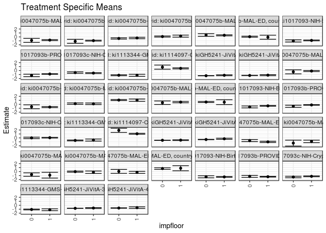

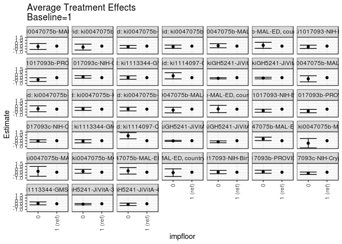

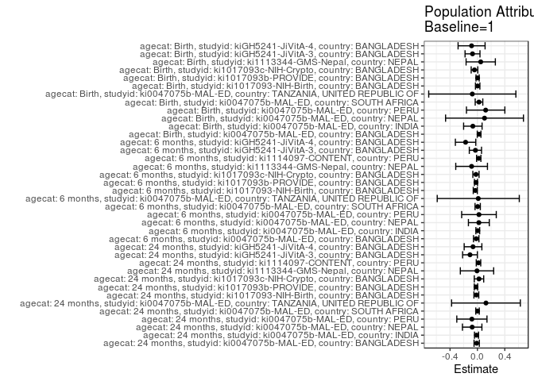

## Results Table

### Parameter: TSM

| agecat | studyid | country | intervention_level | baseline_level | estimate | ci_lower | ci_upper |
| --- | --- | --- | --- | --- | --- | --- | --- |
| Birth | ki0047075b-MAL-ED | BANGLADESH | 1 | NA | -0.9972937 | -1.1571246 | -0.8374629 |
| Birth | ki0047075b-MAL-ED | BANGLADESH | 0 | NA | -0.6745061 | -0.9288398 | -0.4201723 |
| Birth | ki0047075b-MAL-ED | INDIA | 1 | NA | -0.8772727 | -1.1935310 | -0.5610144 |
| Birth | ki0047075b-MAL-ED | INDIA | 0 | NA | -1.3116667 | -2.0623390 | -0.5609943 |
| Birth | ki0047075b-MAL-ED | NEPAL | 1 | NA | -0.9125000 | -1.6413488 | -0.1836512 |
| Birth | ki0047075b-MAL-ED | NEPAL | 0 | NA | -0.7568750 | -1.1980753 | -0.3156747 |
| Birth | ki0047075b-MAL-ED | PERU | 1 | NA | -0.1672230 | -0.4768926 | 0.1424467 |
| Birth | ki0047075b-MAL-ED | PERU | 0 | NA | -0.0124662 | -0.1486997 | 0.1237673 |
| Birth | ki0047075b-MAL-ED | SOUTH AFRICA | 1 | NA | -0.1959302 | -0.4617510 | 0.0698905 |
| Birth | ki0047075b-MAL-ED | SOUTH AFRICA | 0 | NA | 0.0466667 | -0.4532880 | 0.5466213 |
| Birth | ki0047075b-MAL-ED | TANZANIA, UNITED REPUBLIC OF | 1 | NA | 0.8440000 | 0.2094403 | 1.4785597 |
| Birth | ki0047075b-MAL-ED | TANZANIA, UNITED REPUBLIC OF | 0 | NA | 0.7655660 | 0.5608207 | 0.9703114 |
| Birth | ki1017093-NIH-Birth | BANGLADESH | 1 | NA | -1.3484516 | -1.4504133 | -1.2464899 |
| Birth | ki1017093-NIH-Birth | BANGLADESH | 0 | NA | -1.3206115 | -1.5832393 | -1.0579837 |
| Birth | ki1017093b-PROVIDE | BANGLADESH | 1 | NA | -1.3010349 | -1.3814610 | -1.2206088 |
| Birth | ki1017093b-PROVIDE | BANGLADESH | 0 | NA | -1.2190614 | -1.4688838 | -0.9692391 |
| Birth | ki1017093c-NIH-Crypto | BANGLADESH | 1 | NA | -1.2013900 | -1.2967821 | -1.1059979 |
| Birth | ki1017093c-NIH-Crypto | BANGLADESH | 0 | NA | -1.3780565 | -1.5667972 | -1.1893159 |
| Birth | ki1113344-GMS-Nepal | NEPAL | 1 | NA | -1.1342431 | -1.3665469 | -0.9019394 |
| Birth | ki1113344-GMS-Nepal | NEPAL | 0 | NA | -1.0708683 | -1.1792298 | -0.9625069 |
| Birth | kiGH5241-JiVitA-3 | BANGLADESH | 1 | NA | -0.7056704 | -0.8163061 | -0.5950347 |
| Birth | kiGH5241-JiVitA-3 | BANGLADESH | 0 | NA | -0.7807035 | -0.8005483 | -0.7608587 |
| Birth | kiGH5241-JiVitA-4 | BANGLADESH | 1 | NA | -0.6029805 | -0.8087912 | -0.3971697 |
| Birth | kiGH5241-JiVitA-4 | BANGLADESH | 0 | NA | -0.7025755 | -0.7597817 | -0.6453693 |
| 6 months | ki0047075b-MAL-ED | BANGLADESH | 1 | NA | -0.1156817 | -0.2497213 | 0.0183579 |
| 6 months | ki0047075b-MAL-ED | BANGLADESH | 0 | NA | -0.3184935 | -0.8305554 | 0.1935684 |
| 6 months | ki0047075b-MAL-ED | INDIA | 1 | NA | -0.7154674 | -0.8480742 | -0.5828606 |
| 6 months | ki0047075b-MAL-ED | INDIA | 0 | NA | -0.6451398 | -1.1409678 | -0.1493118 |
| 6 months | ki0047075b-MAL-ED | NEPAL | 1 | NA | 0.1071675 | -0.0902517 | 0.3045868 |
| 6 months | ki0047075b-MAL-ED | NEPAL | 0 | NA | 0.1504604 | -0.0337714 | 0.3346922 |
| 6 months | ki0047075b-MAL-ED | PERU | 1 | NA | 1.0285284 | 0.7396987 | 1.3173582 |
| 6 months | ki0047075b-MAL-ED | PERU | 0 | NA | 1.0493208 | 0.9125847 | 1.1860570 |
| 6 months | ki0047075b-MAL-ED | SOUTH AFRICA | 1 | NA | 0.5365664 | 0.3731532 | 0.6999795 |
| 6 months | ki0047075b-MAL-ED | SOUTH AFRICA | 0 | NA | 0.3769383 | -0.0742553 | 0.8281319 |
| 6 months | ki0047075b-MAL-ED | TANZANIA, UNITED REPUBLIC OF | 1 | NA | 0.5232949 | -0.0941025 | 1.1406924 |
| 6 months | ki0047075b-MAL-ED | TANZANIA, UNITED REPUBLIC OF | 0 | NA | 0.5573108 | 0.4222821 | 0.6923395 |
| 6 months | ki1017093-NIH-Birth | BANGLADESH | 1 | NA | -0.4133126 | -0.5100344 | -0.3165909 |
| 6 months | ki1017093-NIH-Birth | BANGLADESH | 0 | NA | -0.6826928 | -0.9259040 | -0.4394816 |
| 6 months | ki1017093b-PROVIDE | BANGLADESH | 1 | NA | -0.1780797 | -0.2645621 | -0.0915973 |
| 6 months | ki1017093b-PROVIDE | BANGLADESH | 0 | NA | -0.5109744 | -0.7855625 | -0.2363863 |
| 6 months | ki1017093c-NIH-Crypto | BANGLADESH | 1 | NA | 0.0512883 | -0.0383614 | 0.1409380 |
| 6 months | ki1017093c-NIH-Crypto | BANGLADESH | 0 | NA | 0.0051205 | -0.1795032 | 0.1897442 |
| 6 months | ki1113344-GMS-Nepal | NEPAL | 1 | NA | -0.5423771 | -0.7967691 | -0.2879850 |
| 6 months | ki1113344-GMS-Nepal | NEPAL | 0 | NA | -0.6381118 | -0.7471653 | -0.5290583 |
| 6 months | ki1114097-CONTENT | PERU | 1 | NA | 1.0491485 | 0.9282212 | 1.1700758 |
| 6 months | ki1114097-CONTENT | PERU | 0 | NA | 1.9147154 | 1.3899338 | 2.4394969 |
| 6 months | kiGH5241-JiVitA-3 | BANGLADESH | 1 | NA | -0.5632946 | -0.6539488 | -0.4726403 |
| 6 months | kiGH5241-JiVitA-3 | BANGLADESH | 0 | NA | -0.5950517 | -0.6162304 | -0.5738729 |
| 6 months | kiGH5241-JiVitA-4 | BANGLADESH | 1 | NA | -0.2172063 | -0.3705518 | -0.0638607 |
| 6 months | kiGH5241-JiVitA-4 | BANGLADESH | 0 | NA | -0.4075318 | -0.4523249 | -0.3627388 |
| 24 months | ki0047075b-MAL-ED | BANGLADESH | 1 | NA | -0.8085550 | -0.9349631 | -0.6821469 |
| 24 months | ki0047075b-MAL-ED | BANGLADESH | 0 | NA | -0.8772568 | -1.3825168 | -0.3719969 |
| 24 months | ki0047075b-MAL-ED | INDIA | 1 | NA | -0.9387860 | -1.0590221 | -0.8185499 |
| 24 months | ki0047075b-MAL-ED | INDIA | 0 | NA | -1.1136333 | -1.6157014 | -0.6115652 |
| 24 months | ki0047075b-MAL-ED | NEPAL | 1 | NA | -0.2705194 | -0.4550061 | -0.0860326 |
| 24 months | ki0047075b-MAL-ED | NEPAL | 0 | NA | -0.3962227 | -0.5579702 | -0.2344752 |
| 24 months | ki0047075b-MAL-ED | PERU | 1 | NA | 0.1921075 | -0.0640610 | 0.4482759 |
| 24 months | ki0047075b-MAL-ED | PERU | 0 | NA | 0.0871674 | -0.0525693 | 0.2269041 |
| 24 months | ki0047075b-MAL-ED | SOUTH AFRICA | 1 | NA | 0.4077261 | 0.2787272 | 0.5367251 |
| 24 months | ki0047075b-MAL-ED | SOUTH AFRICA | 0 | NA | 0.4812634 | 0.1540875 | 0.8084392 |
| 24 months | ki0047075b-MAL-ED | TANZANIA, UNITED REPUBLIC OF | 1 | NA | -0.0770945 | -0.5848270 | 0.4306379 |
| 24 months | ki0047075b-MAL-ED | TANZANIA, UNITED REPUBLIC OF | 0 | NA | 0.0560120 | -0.0738064 | 0.1858304 |
| 24 months | ki1017093-NIH-Birth | BANGLADESH | 1 | NA | -0.8949191 | -0.9998541 | -0.7899840 |
| 24 months | ki1017093-NIH-Birth | BANGLADESH | 0 | NA | -1.0153489 | -1.2890245 | -0.7416732 |
| 24 months | ki1017093b-PROVIDE | BANGLADESH | 1 | NA | -0.8717037 | -0.9575339 | -0.7858735 |
| 24 months | ki1017093b-PROVIDE | BANGLADESH | 0 | NA | -1.2224614 | -1.5388450 | -0.9060778 |
| 24 months | ki1017093c-NIH-Crypto | BANGLADESH | 1 | NA | -0.6331920 | -0.7512761 | -0.5151078 |
| 24 months | ki1017093c-NIH-Crypto | BANGLADESH | 0 | NA | -0.5121413 | -0.7033635 | -0.3209192 |
| 24 months | ki1113344-GMS-Nepal | NEPAL | 1 | NA | -1.1928900 | -1.4576075 | -0.9281726 |
| 24 months | ki1113344-GMS-Nepal | NEPAL | 0 | NA | -1.1785839 | -1.2965240 | -1.0606437 |
| 24 months | ki1114097-CONTENT | PERU | 1 | NA | 0.5511573 | 0.4090462 | 0.6932683 |
| 24 months | ki1114097-CONTENT | PERU | 0 | NA | 0.8704787 | 0.3479340 | 1.3930235 |
| 24 months | kiGH5241-JiVitA-3 | BANGLADESH | 1 | NA | -1.1885274 | -1.3005181 | -1.0765368 |
| 24 months | kiGH5241-JiVitA-3 | BANGLADESH | 0 | NA | -1.3019663 | -1.3259225 | -1.2780100 |
| 24 months | kiGH5241-JiVitA-4 | BANGLADESH | 1 | NA | -1.1589221 | -1.2928771 | -1.0249670 |
| 24 months | kiGH5241-JiVitA-4 | BANGLADESH | 0 | NA | -1.2344071 | -1.2713099 | -1.1975043 |

### Parameter: E(Y)

| agecat | studyid | country | intervention_level | baseline_level | estimate | ci_lower | ci_upper |
| --- | --- | --- | --- | --- | --- | --- | --- |
| Birth | ki0047075b-MAL-ED | BANGLADESH | NA | NA | -0.9728358 | -1.1217009 | -0.8239707 |
| Birth | ki0047075b-MAL-ED | INDIA | NA | NA | -0.9441026 | -1.2397919 | -0.6484132 |
| Birth | ki0047075b-MAL-ED | NEPAL | NA | NA | -0.8087500 | -1.1914221 | -0.4260779 |
| Birth | ki0047075b-MAL-ED | PERU | NA | NA | -0.0468095 | -0.1738806 | 0.0802616 |
| Birth | ki0047075b-MAL-ED | SOUTH AFRICA | NA | NA | -0.1729474 | -0.4186222 | 0.0727275 |
| Birth | ki0047075b-MAL-ED | TANZANIA, UNITED REPUBLIC OF | NA | NA | 0.7690991 | 0.5714748 | 0.9667234 |
| Birth | ki1017093-NIH-Birth | BANGLADESH | NA | NA | -1.3448514 | -1.4396716 | -1.2500312 |
| Birth | ki1017093b-PROVIDE | BANGLADESH | NA | NA | -1.2984586 | -1.3752758 | -1.2216415 |
| Birth | ki1017093c-NIH-Crypto | BANGLADESH | NA | NA | -1.2441513 | -1.3281130 | -1.1601897 |
| Birth | ki1113344-GMS-Nepal | NEPAL | NA | NA | -1.0860636 | -1.1830454 | -0.9890818 |
| Birth | kiGH5241-JiVitA-3 | BANGLADESH | NA | NA | -0.7773511 | -0.7963777 | -0.7583245 |
| Birth | kiGH5241-JiVitA-4 | BANGLADESH | NA | NA | -0.6882498 | -0.7406539 | -0.6358456 |
| 6 months | ki0047075b-MAL-ED | BANGLADESH | NA | NA | -0.1333333 | -0.2623761 | -0.0042906 |
| 6 months | ki0047075b-MAL-ED | INDIA | NA | NA | -0.7102872 | -0.8371659 | -0.5834085 |
| 6 months | ki0047075b-MAL-ED | NEPAL | NA | NA | 0.1281441 | -0.0056126 | 0.2619008 |
| 6 months | ki0047075b-MAL-ED | PERU | NA | NA | 1.0512099 | 0.9285617 | 1.1738581 |
| 6 months | ki0047075b-MAL-ED | SOUTH AFRICA | NA | NA | 0.5404351 | 0.3867005 | 0.6941696 |
| 6 months | ki0047075b-MAL-ED | TANZANIA, UNITED REPUBLIC OF | NA | NA | 0.5355782 | 0.4032519 | 0.6679046 |
| 6 months | ki1017093-NIH-Birth | BANGLADESH | NA | NA | -0.4447399 | -0.5354039 | -0.3540758 |
| 6 months | ki1017093b-PROVIDE | BANGLADESH | NA | NA | -0.1990907 | -0.2817968 | -0.1163845 |
| 6 months | ki1017093c-NIH-Crypto | BANGLADESH | NA | NA | 0.0297622 | -0.0491685 | 0.1086930 |
| 6 months | ki1113344-GMS-Nepal | NEPAL | NA | NA | -0.6273772 | -0.7253868 | -0.5293676 |
| 6 months | ki1114097-CONTENT | PERU | NA | NA | 1.0684318 | 0.9515274 | 1.1853362 |
| 6 months | kiGH5241-JiVitA-3 | BANGLADESH | NA | NA | -0.5926720 | -0.6122891 | -0.5730549 |
| 6 months | kiGH5241-JiVitA-4 | BANGLADESH | NA | NA | -0.3901347 | -0.4273932 | -0.3528762 |
| 24 months | ki0047075b-MAL-ED | BANGLADESH | NA | NA | -0.8192925 | -0.9412667 | -0.6973182 |
| 24 months | ki0047075b-MAL-ED | INDIA | NA | NA | -0.9516520 | -1.0670654 | -0.8362385 |
| 24 months | ki0047075b-MAL-ED | NEPAL | NA | NA | -0.3471493 | -0.4618867 | -0.2324120 |
| 24 months | ki0047075b-MAL-ED | PERU | NA | NA | 0.1111982 | -0.0118399 | 0.2342362 |
| 24 months | ki0047075b-MAL-ED | SOUTH AFRICA | NA | NA | 0.4090301 | 0.2879441 | 0.5301161 |
| 24 months | ki0047075b-MAL-ED | TANZANIA, UNITED REPUBLIC OF | NA | NA | 0.0477437 | -0.0779935 | 0.1734809 |
| 24 months | ki1017093-NIH-Birth | BANGLADESH | NA | NA | -0.9106710 | -1.0090143 | -0.8123277 |
| 24 months | ki1017093b-PROVIDE | BANGLADESH | NA | NA | -0.8928670 | -0.9755153 | -0.8102187 |
| 24 months | ki1017093c-NIH-Crypto | BANGLADESH | NA | NA | -0.6103502 | -0.7050157 | -0.5156847 |
| 24 months | ki1113344-GMS-Nepal | NEPAL | NA | NA | -1.1990840 | -1.3039914 | -1.0941766 |
| 24 months | ki1114097-CONTENT | PERU | NA | NA | 0.5668293 | 0.4302437 | 0.7034148 |
| 24 months | kiGH5241-JiVitA-3 | BANGLADESH | NA | NA | -1.2970420 | -1.3203145 | -1.2737694 |
| 24 months | kiGH5241-JiVitA-4 | BANGLADESH | NA | NA | -1.2232311 | -1.2550891 | -1.1913732 |

### Parameter: ATE

| agecat | studyid | country | intervention_level | baseline_level | estimate | ci_lower | ci_upper |
| --- | --- | --- | --- | --- | --- | --- | --- |
| Birth | ki0047075b-MAL-ED | BANGLADESH | 1 | 1 | 0.0000000 | 0.0000000 | 0.0000000 |
| Birth | ki0047075b-MAL-ED | BANGLADESH | 0 | 1 | 0.3227877 | 0.0216400 | 0.6239353 |
| Birth | ki0047075b-MAL-ED | INDIA | 1 | 1 | 0.0000000 | 0.0000000 | 0.0000000 |
| Birth | ki0047075b-MAL-ED | INDIA | 0 | 1 | -0.4343939 | -1.2489664 | 0.3801785 |
| Birth | ki0047075b-MAL-ED | NEPAL | 1 | 1 | 0.0000000 | 0.0000000 | 0.0000000 |
| Birth | ki0047075b-MAL-ED | NEPAL | 0 | 1 | 0.1556250 | -0.6963599 | 1.0076099 |
| Birth | ki0047075b-MAL-ED | PERU | 1 | 1 | 0.0000000 | 0.0000000 | 0.0000000 |
| Birth | ki0047075b-MAL-ED | PERU | 0 | 1 | 0.1547567 | -0.1839656 | 0.4934791 |
| Birth | ki0047075b-MAL-ED | SOUTH AFRICA | 1 | 1 | 0.0000000 | 0.0000000 | 0.0000000 |
| Birth | ki0047075b-MAL-ED | SOUTH AFRICA | 0 | 1 | 0.2425969 | -0.3236321 | 0.8088259 |
| Birth | ki0047075b-MAL-ED | TANZANIA, UNITED REPUBLIC OF | 1 | 1 | 0.0000000 | 0.0000000 | 0.0000000 |
| Birth | ki0047075b-MAL-ED | TANZANIA, UNITED REPUBLIC OF | 0 | 1 | -0.0784340 | -0.7452073 | 0.5883394 |
| Birth | ki1017093-NIH-Birth | BANGLADESH | 1 | 1 | 0.0000000 | 0.0000000 | 0.0000000 |
| Birth | ki1017093-NIH-Birth | BANGLADESH | 0 | 1 | 0.0278401 | -0.2539925 | 0.3096727 |
| Birth | ki1017093b-PROVIDE | BANGLADESH | 1 | 1 | 0.0000000 | 0.0000000 | 0.0000000 |
| Birth | ki1017093b-PROVIDE | BANGLADESH | 0 | 1 | 0.0819734 | -0.1800032 | 0.3439500 |
| Birth | ki1017093c-NIH-Crypto | BANGLADESH | 1 | 1 | 0.0000000 | 0.0000000 | 0.0000000 |
| Birth | ki1017093c-NIH-Crypto | BANGLADESH | 0 | 1 | -0.1766665 | -0.3876766 | 0.0343435 |
| Birth | ki1113344-GMS-Nepal | NEPAL | 1 | 1 | 0.0000000 | 0.0000000 | 0.0000000 |
| Birth | ki1113344-GMS-Nepal | NEPAL | 0 | 1 | 0.0633748 | -0.1929011 | 0.3196507 |
| Birth | kiGH5241-JiVitA-3 | BANGLADESH | 1 | 1 | 0.0000000 | 0.0000000 | 0.0000000 |
| Birth | kiGH5241-JiVitA-3 | BANGLADESH | 0 | 1 | -0.0750331 | -0.1878867 | 0.0378205 |
| Birth | kiGH5241-JiVitA-4 | BANGLADESH | 1 | 1 | 0.0000000 | 0.0000000 | 0.0000000 |
| Birth | kiGH5241-JiVitA-4 | BANGLADESH | 0 | 1 | -0.0995950 | -0.3117645 | 0.1125744 |
| 6 months | ki0047075b-MAL-ED | BANGLADESH | 1 | 1 | 0.0000000 | 0.0000000 | 0.0000000 |
| 6 months | ki0047075b-MAL-ED | BANGLADESH | 0 | 1 | -0.2028118 | -0.7323003 | 0.3266767 |
| 6 months | ki0047075b-MAL-ED | INDIA | 1 | 1 | 0.0000000 | 0.0000000 | 0.0000000 |
| 6 months | ki0047075b-MAL-ED | INDIA | 0 | 1 | 0.0703276 | -0.4431971 | 0.5838523 |
| 6 months | ki0047075b-MAL-ED | NEPAL | 1 | 1 | 0.0000000 | 0.0000000 | 0.0000000 |
| 6 months | ki0047075b-MAL-ED | NEPAL | 0 | 1 | 0.0432929 | -0.2270729 | 0.3136587 |
| 6 months | ki0047075b-MAL-ED | PERU | 1 | 1 | 0.0000000 | 0.0000000 | 0.0000000 |
| 6 months | ki0047075b-MAL-ED | PERU | 0 | 1 | 0.0207924 | -0.2991163 | 0.3407011 |
| 6 months | ki0047075b-MAL-ED | SOUTH AFRICA | 1 | 1 | 0.0000000 | 0.0000000 | 0.0000000 |
| 6 months | ki0047075b-MAL-ED | SOUTH AFRICA | 0 | 1 | -0.1596280 | -0.6418049 | 0.3225488 |
| 6 months | ki0047075b-MAL-ED | TANZANIA, UNITED REPUBLIC OF | 1 | 1 | 0.0000000 | 0.0000000 | 0.0000000 |
| 6 months | ki0047075b-MAL-ED | TANZANIA, UNITED REPUBLIC OF | 0 | 1 | 0.0340158 | -0.5988944 | 0.6669261 |
| 6 months | ki1017093-NIH-Birth | BANGLADESH | 1 | 1 | 0.0000000 | 0.0000000 | 0.0000000 |
| 6 months | ki1017093-NIH-Birth | BANGLADESH | 0 | 1 | -0.2693802 | -0.5312047 | -0.0075556 |
| 6 months | ki1017093b-PROVIDE | BANGLADESH | 1 | 1 | 0.0000000 | 0.0000000 | 0.0000000 |
| 6 months | ki1017093b-PROVIDE | BANGLADESH | 0 | 1 | -0.3328947 | -0.6203478 | -0.0454416 |
| 6 months | ki1017093c-NIH-Crypto | BANGLADESH | 1 | 1 | 0.0000000 | 0.0000000 | 0.0000000 |
| 6 months | ki1017093c-NIH-Crypto | BANGLADESH | 0 | 1 | -0.0461678 | -0.2509905 | 0.1586549 |
| 6 months | ki1113344-GMS-Nepal | NEPAL | 1 | 1 | 0.0000000 | 0.0000000 | 0.0000000 |
| 6 months | ki1113344-GMS-Nepal | NEPAL | 0 | 1 | -0.0957347 | -0.3728120 | 0.1813426 |
| 6 months | ki1114097-CONTENT | PERU | 1 | 1 | 0.0000000 | 0.0000000 | 0.0000000 |
| 6 months | ki1114097-CONTENT | PERU | 0 | 1 | 0.8655669 | 0.3251318 | 1.4060019 |
| 6 months | kiGH5241-JiVitA-3 | BANGLADESH | 1 | 1 | 0.0000000 | 0.0000000 | 0.0000000 |
| 6 months | kiGH5241-JiVitA-3 | BANGLADESH | 0 | 1 | -0.0317571 | -0.1250111 | 0.0614968 |
| 6 months | kiGH5241-JiVitA-4 | BANGLADESH | 1 | 1 | 0.0000000 | 0.0000000 | 0.0000000 |
| 6 months | kiGH5241-JiVitA-4 | BANGLADESH | 0 | 1 | -0.1903256 | -0.3514069 | -0.0292443 |
| 24 months | ki0047075b-MAL-ED | BANGLADESH | 1 | 1 | 0.0000000 | 0.0000000 | 0.0000000 |
| 24 months | ki0047075b-MAL-ED | BANGLADESH | 0 | 1 | -0.0687018 | -0.5901660 | 0.4527624 |
| 24 months | ki0047075b-MAL-ED | INDIA | 1 | 1 | 0.0000000 | 0.0000000 | 0.0000000 |
| 24 months | ki0047075b-MAL-ED | INDIA | 0 | 1 | -0.1748473 | -0.6903735 | 0.3406788 |
| 24 months | ki0047075b-MAL-ED | NEPAL | 1 | 1 | 0.0000000 | 0.0000000 | 0.0000000 |
| 24 months | ki0047075b-MAL-ED | NEPAL | 0 | 1 | -0.1257033 | -0.3701259 | 0.1187193 |
| 24 months | ki0047075b-MAL-ED | PERU | 1 | 1 | 0.0000000 | 0.0000000 | 0.0000000 |
| 24 months | ki0047075b-MAL-ED | PERU | 0 | 1 | -0.1049401 | -0.3956127 | 0.1857325 |
| 24 months | ki0047075b-MAL-ED | SOUTH AFRICA | 1 | 1 | 0.0000000 | 0.0000000 | 0.0000000 |
| 24 months | ki0047075b-MAL-ED | SOUTH AFRICA | 0 | 1 | 0.0735372 | -0.2803343 | 0.4274088 |
| 24 months | ki0047075b-MAL-ED | TANZANIA, UNITED REPUBLIC OF | 1 | 1 | 0.0000000 | 0.0000000 | 0.0000000 |
| 24 months | ki0047075b-MAL-ED | TANZANIA, UNITED REPUBLIC OF | 0 | 1 | 0.1331065 | -0.3914696 | 0.6576826 |
| 24 months | ki1017093-NIH-Birth | BANGLADESH | 1 | 1 | 0.0000000 | 0.0000000 | 0.0000000 |
| 24 months | ki1017093-NIH-Birth | BANGLADESH | 0 | 1 | -0.1204298 | -0.4138918 | 0.1730322 |
| 24 months | ki1017093b-PROVIDE | BANGLADESH | 1 | 1 | 0.0000000 | 0.0000000 | 0.0000000 |
| 24 months | ki1017093b-PROVIDE | BANGLADESH | 0 | 1 | -0.3507577 | -0.6789184 | -0.0225970 |
| 24 months | ki1017093c-NIH-Crypto | BANGLADESH | 1 | 1 | 0.0000000 | 0.0000000 | 0.0000000 |
| 24 months | ki1017093c-NIH-Crypto | BANGLADESH | 0 | 1 | 0.1210506 | -0.1032199 | 0.3453212 |
| 24 months | ki1113344-GMS-Nepal | NEPAL | 1 | 1 | 0.0000000 | 0.0000000 | 0.0000000 |
| 24 months | ki1113344-GMS-Nepal | NEPAL | 0 | 1 | 0.0143061 | -0.2763939 | 0.3050061 |
| 24 months | ki1114097-CONTENT | PERU | 1 | 1 | 0.0000000 | 0.0000000 | 0.0000000 |
| 24 months | ki1114097-CONTENT | PERU | 0 | 1 | 0.3193214 | -0.2232016 | 0.8618445 |
| 24 months | kiGH5241-JiVitA-3 | BANGLADESH | 1 | 1 | 0.0000000 | 0.0000000 | 0.0000000 |
| 24 months | kiGH5241-JiVitA-3 | BANGLADESH | 0 | 1 | -0.1134389 | -0.2259520 | -0.0009257 |
| 24 months | kiGH5241-JiVitA-4 | BANGLADESH | 1 | 1 | 0.0000000 | 0.0000000 | 0.0000000 |
| 24 months | kiGH5241-JiVitA-4 | BANGLADESH | 0 | 1 | -0.0754850 | -0.2134292 | 0.0624592 |

### Parameter: PAR

| agecat | studyid | country | intervention_level | baseline_level | estimate | ci_lower | ci_upper |
| --- | --- | --- | --- | --- | --- | --- | --- |
| Birth | ki0047075b-MAL-ED | BANGLADESH | 1 | NA | 0.0244579 | -0.0024172 | 0.0513330 |
| Birth | ki0047075b-MAL-ED | INDIA | 1 | NA | -0.0668298 | -0.2016929 | 0.0680332 |
| Birth | ki0047075b-MAL-ED | NEPAL | 1 | NA | 0.1037500 | -0.4650307 | 0.6725307 |
| Birth | ki0047075b-MAL-ED | PERU | 1 | NA | 0.1204134 | -0.1601319 | 0.4009587 |
| Birth | ki0047075b-MAL-ED | SOUTH AFRICA | 1 | NA | 0.0229829 | -0.0325492 | 0.0785150 |
| Birth | ki0047075b-MAL-ED | TANZANIA, UNITED REPUBLIC OF | 1 | NA | -0.0749009 | -0.7116467 | 0.5618449 |
| Birth | ki1017093-NIH-Birth | BANGLADESH | 1 | NA | 0.0036002 | -0.0286457 | 0.0358462 |
| Birth | ki1017093b-PROVIDE | BANGLADESH | 1 | NA | 0.0025762 | -0.0209300 | 0.0260825 |
| Birth | ki1017093c-NIH-Crypto | BANGLADESH | 1 | NA | -0.0427613 | -0.0911840 | 0.0056613 |
| Birth | ki1113344-GMS-Nepal | NEPAL | 1 | NA | 0.0481795 | -0.1656433 | 0.2620024 |
| Birth | kiGH5241-JiVitA-3 | BANGLADESH | 1 | NA | -0.0716807 | -0.1806372 | 0.0372758 |
| Birth | kiGH5241-JiVitA-4 | BANGLADESH | 1 | NA | -0.0852693 | -0.2824698 | 0.1119312 |
| 6 months | ki0047075b-MAL-ED | BANGLADESH | 1 | NA | -0.0176516 | -0.0574105 | 0.0221073 |
| 6 months | ki0047075b-MAL-ED | INDIA | 1 | NA | 0.0051802 | -0.0225019 | 0.0328623 |
| 6 months | ki0047075b-MAL-ED | NEPAL | 1 | NA | 0.0209766 | -0.1315309 | 0.1734841 |
| 6 months | ki0047075b-MAL-ED | PERU | 1 | NA | 0.0226815 | -0.2300370 | 0.2753999 |
| 6 months | ki0047075b-MAL-ED | SOUTH AFRICA | 1 | NA | 0.0038687 | -0.0346875 | 0.0424249 |
| 6 months | ki0047075b-MAL-ED | TANZANIA, UNITED REPUBLIC OF | 1 | NA | 0.0122833 | -0.5872864 | 0.6118529 |
| 6 months | ki1017093-NIH-Birth | BANGLADESH | 1 | NA | -0.0314272 | -0.0611639 | -0.0016906 |
| 6 months | ki1017093b-PROVIDE | BANGLADESH | 1 | NA | -0.0210110 | -0.0436640 | 0.0016420 |
| 6 months | ki1017093c-NIH-Crypto | BANGLADESH | 1 | NA | -0.0215261 | -0.0668850 | 0.0238329 |
| 6 months | ki1113344-GMS-Nepal | NEPAL | 1 | NA | -0.0850001 | -0.3165831 | 0.1465829 |
| 6 months | ki1114097-CONTENT | PERU | 1 | NA | 0.0192833 | -0.0121770 | 0.0507435 |
| 6 months | kiGH5241-JiVitA-3 | BANGLADESH | 1 | NA | -0.0293774 | -0.1186561 | 0.0599012 |
| 6 months | kiGH5241-JiVitA-4 | BANGLADESH | 1 | NA | -0.1729284 | -0.3219733 | -0.0238834 |
| 24 months | ki0047075b-MAL-ED | BANGLADESH | 1 | NA | -0.0107374 | -0.0494714 | 0.0279965 |
| 24 months | ki0047075b-MAL-ED | INDIA | 1 | NA | -0.0128660 | -0.0429752 | 0.0172432 |
| 24 months | ki0047075b-MAL-ED | NEPAL | 1 | NA | -0.0766300 | -0.2186815 | 0.0654216 |
| 24 months | ki0047075b-MAL-ED | PERU | 1 | NA | -0.0809093 | -0.3013152 | 0.1394967 |
| 24 months | ki0047075b-MAL-ED | SOUTH AFRICA | 1 | NA | 0.0013040 | -0.0243837 | 0.0269916 |
| 24 months | ki0047075b-MAL-ED | TANZANIA, UNITED REPUBLIC OF | 1 | NA | 0.1248382 | -0.3772037 | 0.6268802 |
| 24 months | ki1017093-NIH-Birth | BANGLADESH | 1 | NA | -0.0157519 | -0.0511463 | 0.0196425 |
| 24 months | ki1017093b-PROVIDE | BANGLADESH | 1 | NA | -0.0211633 | -0.0462239 | 0.0038973 |
| 24 months | ki1017093c-NIH-Crypto | BANGLADESH | 1 | NA | 0.0228418 | -0.0460096 | 0.0916931 |
| 24 months | ki1113344-GMS-Nepal | NEPAL | 1 | NA | -0.0061940 | -0.2496136 | 0.2372256 |
| 24 months | ki1114097-CONTENT | PERU | 1 | NA | 0.0156720 | -0.0170253 | 0.0483692 |
| 24 months | kiGH5241-JiVitA-3 | BANGLADESH | 1 | NA | -0.1085145 | -0.2164252 | -0.0006039 |
| 24 months | kiGH5241-JiVitA-4 | BANGLADESH | 1 | NA | -0.0643090 | -0.1935321 | 0.0649141 |